**MDFF_NM Tutorial**

### **Introduction**

This tutorial provides an introduction to the basic usage of [MDFF_NM](https://pubs.acs.org/doi/10.1021/acs.jcim.3c02007?goto=supporting-info)<sup>1</sup>, an extension of the original Molecular Dynamics Flexible Fitting method<sup>2</sup> implemented in the VMD/NAMD ecosystem.

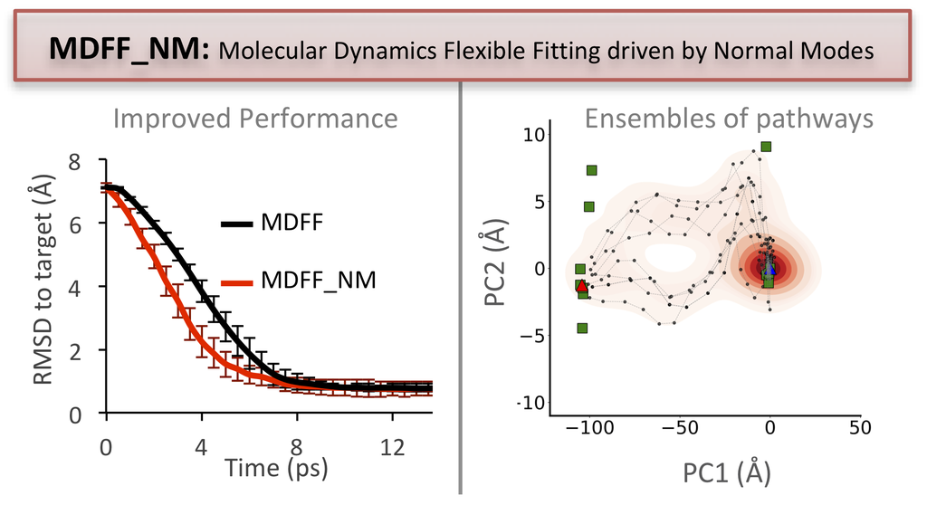

Molecular Dynamics Flexible Fitting (MDFF) is a widely used tool to refine high-resolution structures into cryo-EM density maps. Despite many successful applications, MDFF is still limited by its high computational cost, overfitting, accuracy, and performance issues due to entrapment within wrong local minima. Modern ensemble-based MDFF tools have generated promising results in the past decade. In line with these studies, we present MDFF_NM, a stochastic hybrid flexible fitting algorithm combining Normal Mode Analysis (NMA) and simulation-based flexible fitting. Initial tests reveal that, besides accelerating the fitting process, MDFF_NM increases the diversity of fitting routes leading to the target, uncovering ensembles of conformations in closer agreement with experimental data.

All input/output manipulations, normal modes and linear algebra calculations are carried out with the R software using its internal functions and the routines included in the bio3d package<sup>3</sup>,<sup>4</sup>.

### **Requirements**

#### **install R**

R can be easily installed through the package manager. Alternatively, it may also be downloaded from the [R-project web site](https://www.r-project.org/).

```r
apt-get install r-base-core
```

#### **install the Bio3D package**

To obtain the Bio3D package, start R and then type the following line:

```r
install.packages("bio3d")
```

Additional instructions for obtaining and installing the Bio3D package can be found in the [Installing Bio3D Vignette](http://thegrantlab.org/bio3d/tutorials).

#### **install VMD 1.9.4**

[Installation instructions](https://www.ks.uiuc.edu/Research/vmd/)

#### **install NAMD**

Download the [NAMD executable](http://www.ks.uiuc.edu/Development/Download/download.cgi?PackageName=NAMD).

To invoke NAMD from R, we advise users to edit the bash_profile file entering the place where the namd2 executable is found:

```r
export PATH="/path-to-namd-executable/:$PATH"
```

#### **Download CatDCD**

We also strongly encourage users to download the [catdcd](https://www.ks.uiuc.edu/Development/MDTools/catdcd/) executable for analysis of trajectories nd make it accesible from everywhere. Again users should edit the bashrc file and enter the line below.

```r
export PATH="/path-to-catdcd-executable/:$PATH"
```

### **Before starting**

In this tutorial we selected the adenylate kinase protein (ADK) as test system as described in the original [MDFF tutorial](https://www.ks.uiuc.edu/Training/Tutorials/science/mdff/tutorial_mdff-html/). We strongly encourage users to follow the tutorial (at least going through the item 2 [“A simple MDFF Example”](https://www.ks.uiuc.edu/Training/Tutorials/science/mdff/tutorial_mdff-html/node4.html)) before testing MDFF_NM.

Both MDFF and MDFF_NM are usually applied to fit an atomic structure into a low-resolution density map of the same macromolecule imaged in a different conformation. Here, the closed ADK state was taken as initial coordinates, but instead of using an actual EM target map, a synthetic (theoretical) map will be generated from the ADK coordinates in the open state.

All routines related to generation and manipulation of EM maps are executed following the original MDFF tutorial. We provide in the **files* folder all .tcl and shell scripts required to execute these steps.

**Preparation**

Before runnning MDFF_NM simulations, users must carry out an equilibration procedure. The current version requires both atomic coordinates and velocities in PDB format (NAMD automatically writes them as .coor and .vel, respectively). Here, the pre-generated required files can be found in the **inputs** folder. The **target structure (4ake.pdb)** considered for generation of target maps is also found in the same folder.

### **Running MDFF_NM**

The current **MDFf_NM** version works as a R script. Here is an example of the files that should be included in the files folder:

```r
mdff_nm.R                           # MDFF_NM script (must NOT be edited)
inputs_mdff_nm.R                    # input file to be edited by users
functions_mdff_nm.R                 # MDFF_NM subroutines (must NOT be edited)
config.namd                         # NAMD configuration file

template_prepare.tcl                # scripts to call VMD and run preparation steps
prepare.sh

get_ccc.tcl                         # scripts to call VMD and calculate cross correlations
ccc.sh                              #      for intermediate structures

template_restraints.tcl             # scripts to call VMD and generate restraints
restraints.sh
par_all36_prot.prm                  # force field parameters to run NAMD
```

```r
# MDFF_NM Arguments
# user defined PARAMETERS
coor.pdb = "adk-equi.pdb"       # initial coordinates of the system (PDB format)
vel.pdb = "adk-equi.vel"        # initial velocities of the system (PDB format)
seg.user = 'AP1'                # segment of the protein to be considered
expmap = "4ake_target"          # filename for the experimental map
target.pdb = "4ake_target.pdb"  # filename for the experimental map
topol = "initial.psf"           # psf file that will be generated (do not edit in the tutorial)
res = 5                         # resolution of the EM density map to be generated

##########  NM-driven exploration ###################################
steps.md = 1000                 # steps per MD excitation cycle
percent.modes = 0.01            # percentage of modes to define a subsert of relevant directions
trial.vector.modes = 3          # number of modes to be considered when building linear cobinations
ek = 50                         # kintic energy to be added along the linear combination of modes
maxcycles = 20                  # maximun number of cycles
######################################################################

####### NAMD parameters##############################################
g_scale = 0.3                  # grid scaling forces - biasing potential
k_prot = 200                   # force constant to restrain dihedrals (default: 200)
hbbondk = 20
hbanglek = 20                    # force constants to restrain H-bonds> (default: 20.0)
freq.out = 20                  # frequency of MD outputs
langevin = 1                   # langevin thermostat gamma parameter
######################################################################

######################  execution MD  ######################################
# the command line for executing MD should be inserted
# in quotes as given in the example below
# users may change this according to the resources available

# example for CPU usage
namd.input = "namd2 +p2"
# example for GPU usage
#namd.input = "namd2  +idlepoll +p4 +devices 0"
###########################################################
```

The **config.namd** file may be edited by experienced users to adapt the parameters for their specific needs (i.e. force field paramenters, pressur amd temperature controls, etc). The version provided as example enables the simulation of adenylate kinase in the vaccum.

After setting the user defined parameters in the **inputs_mdff_nm.R** file, MDFF_NM simulations can be launched with the following command (to be typed in the command line):

```r
sh run-serial-mdff-nm-final.sh
```

These coordinates from each independnt replicates can be easily concatenated by a large variety of tools. We provide a script based on the [catdcd](https://www.ks.uiuc.edu/Development/MDTools/catdcd/) tool, allowing the concatenation of protein coordinates into a single DCD file per folder.

### **Visualization and analysis**

In the MDFF_NM paper, three descriptors were adopted in the assessment of both methods: (i) the cross correlations (c.c) with the EM map, (ii) the Root Mean Square Deviation (RMSD) with respect to the structure considered to produce the target map and the [molprobity score](http://molprobity.biochem.duke.edu/), providing an estimation of the overall structural quality of the generated conformers.

The detailed instructions for the visualization of generated trajectories and calculation of cross correlations are given in the [MDFF tutorial]((https://www.ks.uiuc.edu/Training/Tutorials/science/mdff/tutorial_mdff-html/). Here, users can run the RMSD calculations taking as reference the ADK open state (4ake) considered for the production of the synthetic map. The provided script will generate a **results** where the concatenated trajectories per replicate will be found together with the respective rmsd results in .txt format. To run this script type:

```r
sh rmsd_multireplica_MDFF_NM.sh
```

To visualize the trajectory of the first replicate in VMD type the following command:

```r
vmd ../cycle_0.pdb 1.trr
```

The trajectories of each replicate are numbered to facilitate tracking of the results.

The [xmgrace](https://plasma-gate.weizmann.ac.il/Grace/) tool can be used for visualization of the plots generated per replicate:

```r
xmagrace rmsd_1.txt -legend load
```

or to visualize all replicates together:

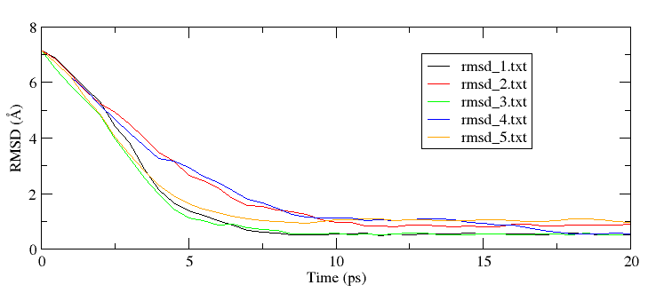

```r
xmagrace rmsd_*.txt -legend load
```

Where the simulation time in picosseconds will be represented in the X-axis and the RMSD to the target structure on the Y-axis.

### **Development Team**

**Mauricio G.S. Costa**

https://orcid.org/0000-0001-5443-286X  
mauricio.costa@fiocruz.br

[figure not shown]

[Programa de Computação Científica (PROCC)](http://www.procc.fiocruz.br)  
Vice-Presidência de Educação, Informação e Comunicação (VPEIC)  
[Fundação Oswaldo Cruz](https://portal.fiocruz.br)

**Zakaria L. Dahmani**

https://orcid.org/0009-0005-8002-3169  
[University of Pittsburgh](https://www.pitt.edu/)

**Financial Support:**

[figure not shown]

### **References**

(1)

Dahmani, Z. L.; Scott, A. L.; Vénien-Bryan, C.; Perahia, D.; Costa, M. G. S. MDFF_NM: Improved Molecular Dynamics Flexible Fitting into Cryo-EM Density Maps with a Multireplica Normal Mode-Based Search. *Journal of Chemical Information and Modeling* **2024**, *64* (13), 5151–5160. https://doi.org/10.1021/acs.jcim.3c02007.

(2)

Trabuco, L. G.; Villa, E.; Mitra, K.; Frank, J.; Schulten, K. Flexible Fitting of Atomic Structures into Electron Microscopy Maps Using Molecular Dynamics. *Structure* **2008**, *16* (5), 673–683. https://doi.org/10.1016/j.str.2008.03.005.

(3)

Grant, B. J.; Rodrigues, A. P. D. C.; Elsawy, K. M.; Mccammon, A. J.; Caves, L. S. D. Bio3d: An r Package for the Comparative Analysis of Protein Structures. *Bioinformatics* **2006**, *22*, 2695–2696. https://doi.org/10.1093/bioinformatics/btl461.

(4)

Skjaerven, L.; Yao, X. Q.; Scarabelli, G.; Grant, B. J. Integrating Protein Structural Dynamics and Evolutionary Analysis with Bio3D. *BMC Bioinformatics* **2015**, *15*, 399. https://doi.org/10.1186/s12859-014-0399-6.